# Sentiment Analysis of A Million News Headlines

2017-11-26

I’ve just finished [R for Data Science](http://r4ds.had.co.nz/) by Hadley Wickham and just started [Text mining With R](http://tidytextmining.com/) by Julia Silge. So I figured it’s about time i do some data analysis to apply the skills I learned. I decided to do sentiment analysis after reading this [post](https://juliasilge.com/blog/life-changing-magic/) by Julia Silge.

After skimming through some interesting datasets on the internet, i decided to use ’A Million Headlines` dataset which can be found on Kaggle. It’s a dataset of news headlines published over a period of 14 years from 2003 to 2017 taken from Australian news source ABC(Australian Broadcasting Group).

First, let’s import all the packages needed:

```r
library(tidyverse)
library(here)
library(tidytext)
library(viridis)
library(widyr)
library(ggraph)
library(igraph)
library(scales)
library(knitr)
library(wordcloud)
library(reshape2)
```

Now let’s import the data

```r
# import data
news <- as.tibble(read_csv(here("abcnews-date-text.csv")))
news
```

```
## # A tibble: 1,103,665 x 2
##    publish_date headline_text
##           <dbl> <chr>
##  1     20030219 aba decides against community broadcasting licence
##  2     20030219 act fire witnesses must be aware of defamation
##  3     20030219 a g calls for infrastructure protection summit
##  4     20030219 air nz staff in aust strike for pay rise
##  5     20030219 air nz strike to affect australian travellers
##  6     20030219 ambitious olsson wins triple jump
##  7     20030219 antic delighted with record breaking barca
##  8     20030219 aussie qualifier stosur wastes four memphis match
##  9     20030219 aust addresses un security council over iraq
## 10     20030219 australia is locked into war timetable opp
## # ... with 1,103,655 more rows
```

# Term Frequency

One of the common task in text mining is to look at word frequencies. Let’s analyze word frequencies in all of the headlines

```r
news <- news %>%
      # create year column
      mutate(year = substr(publish_date,
                start = 1, stop = 4),
                linenumber = row_number())

news
```

```
## # A tibble: 1,103,665 x 4
##    publish_date headline_text                             year  linenumber
##           <dbl> <chr>                                     <chr>      <int>
##  1     20030219 aba decides against community broadcasti… 2003           1
##  2     20030219 act fire witnesses must be aware of defa… 2003           2
##  3     20030219 a g calls for infrastructure protection … 2003           3
##  4     20030219 air nz staff in aust strike for pay rise  2003           4
##  5     20030219 air nz strike to affect australian trave… 2003           5
##  6     20030219 ambitious olsson wins triple jump         2003           6
##  7     20030219 antic delighted with record breaking bar… 2003           7
##  8     20030219 aussie qualifier stosur wastes four memp… 2003           8
##  9     20030219 aust addresses un security council over … 2003           9
## 10     20030219 australia is locked into war timetable o… 2003          10
## # ... with 1,103,655 more rows
```

we can use `unnest_tokens` to separate each line into words. The default tokenizing is for words, but other options include characters, sentences, lines, paragraphs, or separation around regex pattern.

```r
tidy_news <- news %>%
        unnest_tokens(word, headline_text)

tidy_news
```

```
## # A tibble: 7,070,525 x 4
##    publish_date year  linenumber word
##           <dbl> <chr>      <int> <chr>
##  1     20030219 2003           1 aba
##  2     20030219 2003           1 decides
##  3     20030219 2003           1 against
##  4     20030219 2003           1 community
##  5     20030219 2003           1 broadcasting
##  6     20030219 2003           1 licence
##  7     20030219 2003           2 act
##  8     20030219 2003           2 fire
##  9     20030219 2003           2 witnesses
## 10     20030219 2003           2 must
## # ... with 7,070,515 more rows
```

Now we can manipulate the data and do term frequency analysis. First, let’s remove stop words which can be obtain from dataset `stop_words` with the function `anti_join`. Stop words are words which do not contain important significance. We filter out stop words as it could affect our analysis.

```r
# remove stopwords

data("stop_words")
tidy_news <- tidy_news %>%
        anti_join(stop_words)
```

Let’s see the most frequent words use in the news headlines since 2003:

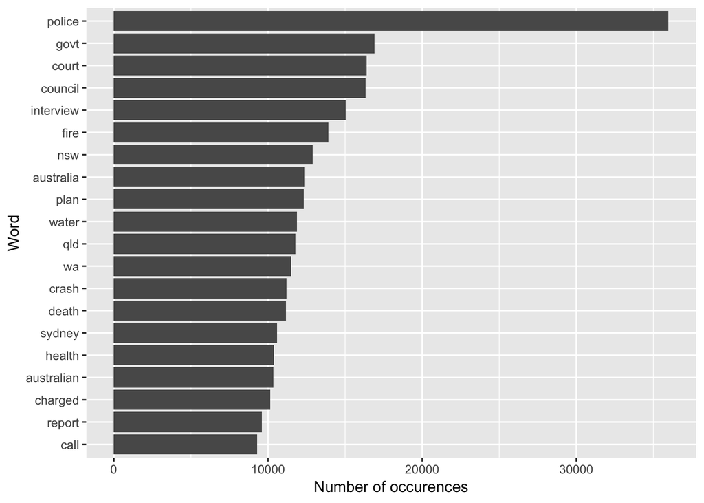

```r
# most common words
tidy_news %>%
    count(word, sort = TRUE) %>%
    head(20) %>%
    mutate(word = reorder(word, n)) %>%
    ggplot(aes(word, n)) +
    geom_bar(stat = "identity") +
    coord_flip() +
    ylab("Number of occurences") +
    xlab("Word")
```

We can see here most of the headlines contain the words, “police”, “court”, “council”.

## Network of Words

Let’s count the words that occur together in the headlines from 2017. Using `pairwise_count` function from `widyr` package, we can count highest co-occurances pair of words.

```r
headlines_2017 <- tidy_news %>%
    filter(year == "2017") %>%
    pairwise_count(word, linenumber, sort = TRUE)

headlines_2017
```

```
## # A tibble: 1,004,826 x 3
##    item1    item2        n
##    <chr>    <chr>    <dbl>
##  1 trump    donald     612
##  2 donald   trump      612
##  3 korea    north      301
##  4 north    korea      301
##  5 marriage sex        285
##  6 sex      marriage   285
##  7 turnbull malcolm    197
##  8 malcolm  turnbull   197
##  9 election wa         149
## 10 wa       election   149
## # ... with 1,004,816 more rows
```

Donald trump is the highest occurences pair of words in 2017 followed by North Korea which unsurprising as the feud between them bring fear about nuclear war around the world. Also in 2017, Australia vote in favour of legalising same sex marriage which is big news across the country. Hence explains why sex marriage is just below Donald Trump and North Korea in frequency of co-occurences pair of words in 2017 headlines.

Let’s plot the network of words occurences:

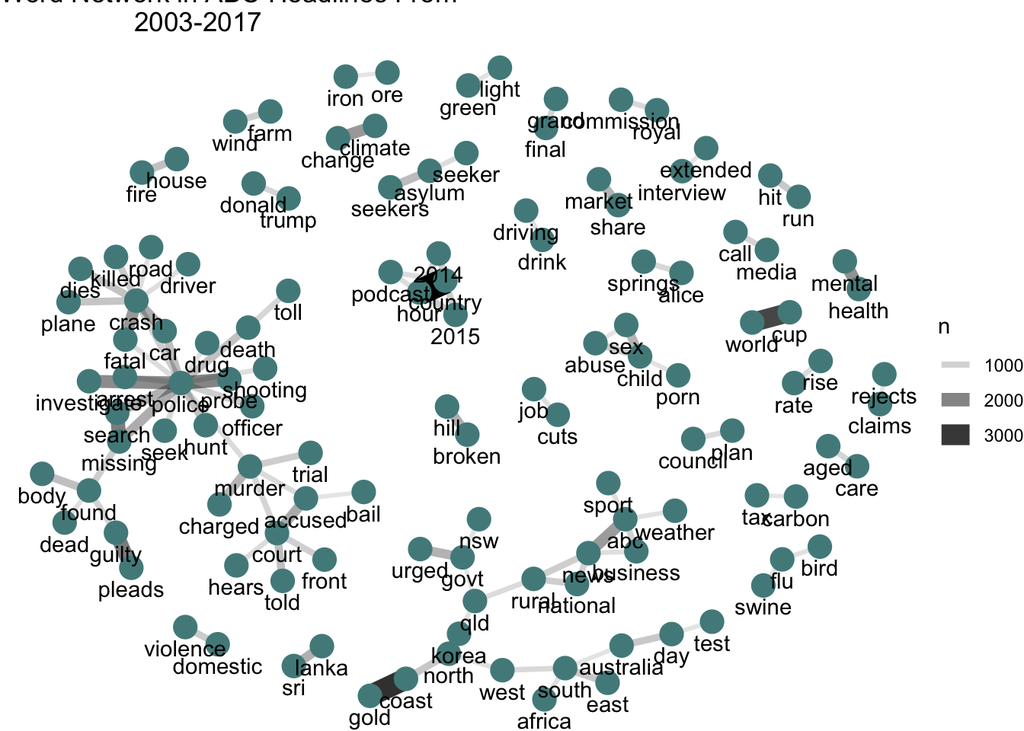

```r
#pairwise count
word_pairs <- tidy_news %>%
  group_by(word) %>%
  filter(n() > 5) %>%
  ungroup() %>%
  pairwise_count(item=word,
                 linenumber, sort = TRUE,
                 upper = FALSE) %>%
  filter(n > 10)

#create plot
word_pairs %>%
  top_n(100) %>%
        graph_from_data_frame() %>%
        ggraph(layout = "fr") +
        geom_edge_link(aes(edge_alpha = n,
                           edge_width = n)) +
        geom_node_point(color = "darkslategray4",
                        size = 5) +
        geom_node_text(aes(label = name),
                       vjust = 1.8) +
        ggtitle(expression(paste(
                  "Word Network in ABC Headlines From
                  2003-2017"))) +
        theme_void()
```

Next, we’ll look into sentiment analysis of these words so we can understand what type of sentiment have been used in most of these headlines.

## Sentiment Analysis

Now let’s investigate sentiment analysis. When we reads a text, we use our understanding of the emotional intent of words to infer wheter a section of words is positive or negative and also categorized it into emotion like anger or joy. Let’s use bing lexicon from `sentiments` dataset to categorized our words into positive or negative sentiment.

```r
# create dataframe of words from bing lexicon
library(tidyr)
bing <- sentiments %>%
        filter(lexicon == "bing") %>%
        select(-score)

bing
```

```
## # A tibble: 6,788 x 3
##    word        sentiment lexicon
##    <chr>       <chr>     <chr>
##  1 2-faced     negative  bing
##  2 2-faces     negative  bing
##  3 a+          positive  bing
##  4 abnormal    negative  bing
##  5 abolish     negative  bing
##  6 abominable  negative  bing
##  7 abominably  negative  bing
##  8 abominate   negative  bing
##  9 abomination negative  bing
## 10 abort       negative  bing
## # ... with 6,778 more rows
```

Using `inner_join` function, we can categorized the words into positive or negative by joining `bing` dataset.

```r
# classified words into positive
## or negative based on bing lexicon
news_sentiment <- tidy_news %>%
        inner_join(bing) %>%
        count(year,sentiment) %>%
        spread(sentiment, n, fill = 0) %>%
        mutate(sentiment = positive - negative)

news_sentiment
```

```
## # A tibble: 15 x 4
##    year  negative positive sentiment
##    <chr>    <dbl>    <dbl>     <dbl>
##  1 2003     26303    12604    -13699
##  2 2004     31093    14291    -16802
##  3 2005     31705    13522    -18183
##  4 2006     28471    12123    -16348
##  5 2007     32875    13454    -19421
##  6 2008     34001    14123    -19878
##  7 2009     32679    13069    -19610
##  8 2010     31273    12589    -18684
##  9 2011     30169    11997    -18172
## 10 2012     30152    13555    -16597
## 11 2013     31884    14523    -17361
## 12 2014     28363    14290    -14073
## 13 2015     30389    14673    -15716
## 14 2016     24249    11487    -12762
## 15 2017     19247     9208    -10039
```

## Most common positive and negative words

Now that we have data frame of positive and negative sentiments, we can analyze which words is most common in the positive and negative category. We can filter out `NA` sentiment or neutral sentiment.

```r
word_count <- tidy_news %>%
  left_join(get_sentiments("bing"), by = "word") %>%
  filter(!is.na(sentiment)) %>%
  count(word, sentiment, sort = TRUE) %>%
  ungroup()

top_sentiments_bing <- word_count %>%
          filter(word != "wins") %>%
          group_by(sentiment) %>%
          top_n(5, n) %>%
          mutate(num = ifelse(sentiment == "negative",
                              -n, n)) %>%
          mutate(word = reorder(word, num)) %>%
          ungroup()

top_sentiments_bing
```

```
## # A tibble: 10 x 4
##    word    sentiment     n    num
##    <chr>   <chr>     <int>  <int>
##  1 crash   negative  11208 -11208
##  2 death   negative  11173 -11173
##  3 murder  negative   9217  -9217
##  4 win     positive   8315   8315
##  5 killed  negative   8129  -8129
##  6 attack  negative   7166  -7166
##  7 boost   positive   6997   6997
##  8 gold    positive   6211   6211
##  9 top     positive   5687   5687
## 10 support positive   5399   5399
```

Let’s see top 5 words from positive and negative sentiment.

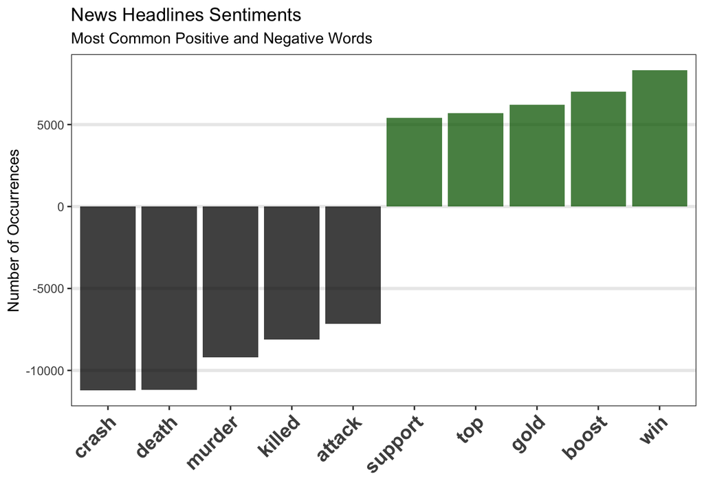

```r
ggplot(top_sentiments_bing, aes(reorder(word, num), num,
                                fill = sentiment)) +
  geom_bar(stat = 'identity', alpha = 0.75) +
  scale_fill_manual(guide = F, values = c("black",
                                          "darkgreen")) +
  scale_y_continuous(breaks = pretty_breaks(7)) +
  labs(x = '', y = "Number of Occurrences",
       title = 'News Headlines Sentiments',
       subtitle = 'Most Common Positive and Negative Words') +
  theme_bw() +
  theme(axis.text.x = element_text(angle = 45, hjust = 1,
                                   size = 14, face = "bold"),
        panel.grid.minor = element_blank(),
        panel.grid.major.x = element_blank(),
        panel.grid.major.y = element_line(size = 1.1))
```

## Word Cloud: Most Common Positive and Negative Words in News Headlines

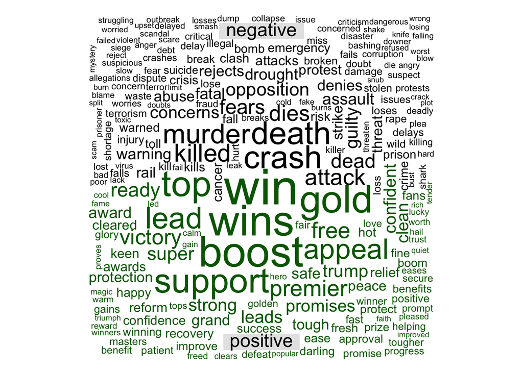

```r
library(wordcloud)   # to create wordcloud
library(reshape2)    # for acast() function

tidy_news %>%
  inner_join(bing) %>%
  count(word, sentiment, sort = TRUE) %>%
  acast(word ~ sentiment, value.var = "n", fill = 0) %>%
  comparison.cloud(colors = c("black", "darkgreen"),
                   title.size = 1.5)
```

## Proportions of Positive and Negative Words

Now let’s see the proportions of negative and positive words to entire data set. after filtering out words categorized as neutral, we calculate the frequency by first grouping them along sentiment then counting the rows for each of these groups. Finally, we can calculate the percentage by dividing the sum of all the rows in the data set.

```r
sentiment_bing <- tidy_news %>%
        left_join(get_sentiments("bing"), by = "word") %>%
        filter(!is.na(sentiment)) %>%
        group_by(year, sentiment) %>%
        summarise(n = n()) %>%
        mutate(percent = n / sum(n)) %>%
        ungroup()

sentiment_bing
```

```
## # A tibble: 30 x 4
##    year  sentiment     n percent
##    <chr> <chr>     <int>   <dbl>
##  1 2003  negative  26303   0.676
##  2 2003  positive  12604   0.324
##  3 2004  negative  31093   0.685
##  4 2004  positive  14291   0.315
##  5 2005  negative  31705   0.701
##  6 2005  positive  13522   0.299
##  7 2006  negative  28471   0.701
##  8 2006  positive  12123   0.299
##  9 2007  negative  32875   0.710
## 10 2007  positive  13454   0.290
## # ... with 20 more rows
```

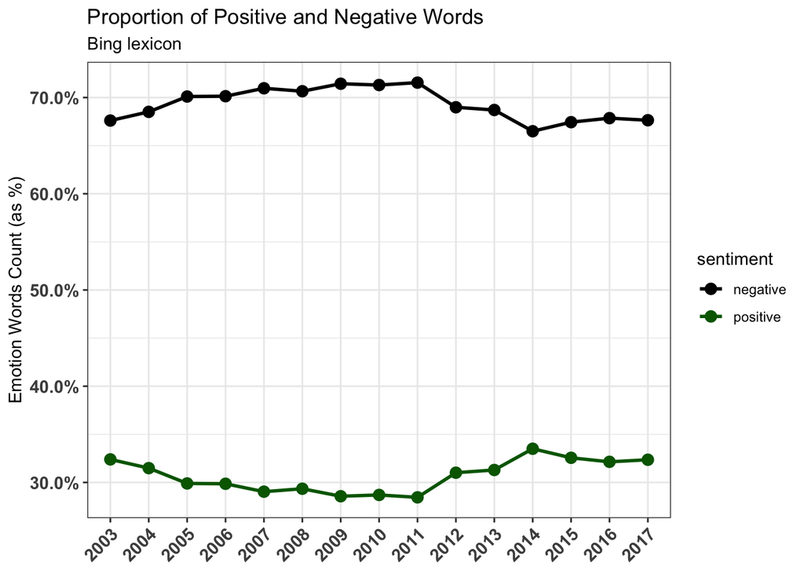

```r
sentiment_bing %>%
  ggplot(aes(x = year, y = percent, color = sentiment,
             group = sentiment)) +
  geom_line(size = 1) +
  geom_point(size = 3) +
  scale_y_continuous(breaks = pretty_breaks(5),
                     labels = percent_format()) +
  labs(x = "Album", y = "Emotion Words Count (as %)") +
  scale_color_manual(values = c(positive = "darkgreen",
                                negative = "black")) +
  ggtitle("Proportion of Positive and Negative Words",
          subtitle = "Bing lexicon") +
  theme_bw() +
  theme(axis.text.x = element_text(angle = 45, hjust = 1,
                                   size = 11, face = "bold"),
        axis.title.x = element_blank(),
        axis.text.y = element_text(size = 11, face = "bold"))
```

The proportion of negative sentiment words has been consistently much higher than proportion of positive sentiment words since 2003.

Let’s use NRC lexicon for sentiment analysis. NRC sentiments got list of sentiments way beyond positive and negative, it categorizes words into eight different emotion terms, `Anger`, `Anticipation`, `Disgust`, `Fear`, `Joy`, `Sadness`, `Surprise`, and `Trust`.

```r
library(RColorBrewer)
cols <- colorRampPalette(brewer.pal(n = 8, name = "Set1"))(8)

cols
```

```
## [1] "#E41A1C" "#377EB8" "#4DAF4A" "#984EA3" "#FF7F00" "#FFFF33" "#A65628"
## [8] "#F781BF"
```

Now, let’s plot the distribution of emotion terms on boxplot:

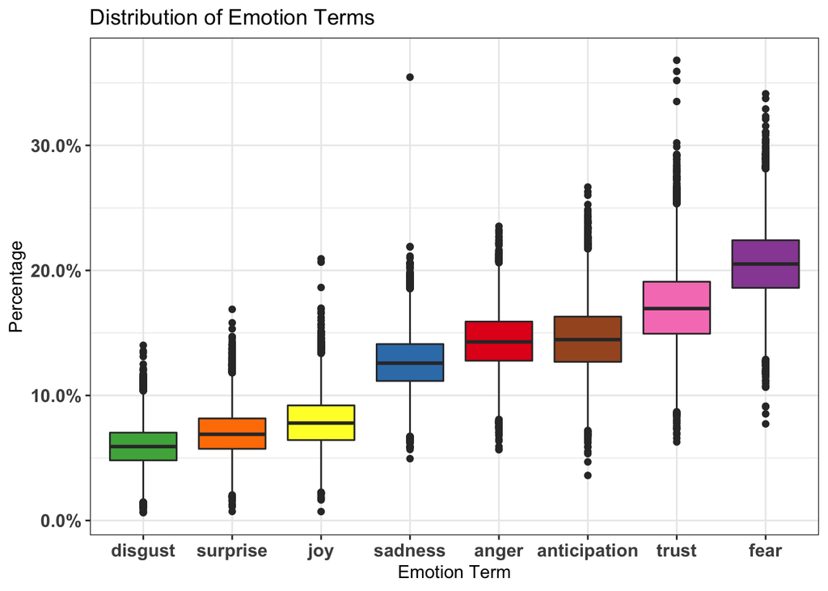

```r
cols <- c("anger" = "#E41A1C", "sadness" = "#377EB8",
          "disgust" = "#4DAF4A", "fear" = "#984EA3",
          "surprise" = "#FF7F00", "joy" = "#FFFF33",
          "anticipation" = "#A65628", "trust" = "#F781BF")

news_nrc <- tidy_news %>%
  left_join(get_sentiments("nrc"), by = "word") %>%
  filter(!(sentiment == "negative" |
           sentiment == "positive")) %>%
  mutate(sentiment = as.factor(sentiment)) %>%
  group_by(index = linenumber %/% 100,
           sentiment) %>%
  summarize(n = n()) %>%
  mutate(percent = n / sum(n)) %>%
  select(-n) %>%
  ungroup()

library(hrbrthemes)

news_nrc %>%
  ggplot() +
  geom_boxplot(aes(x = reorder(sentiment, percent),
                   y = percent, fill = sentiment)) +
  scale_y_continuous(breaks = pretty_breaks(5),
                     labels = percent_format()) +
  scale_fill_manual(values = cols) +
  ggtitle("Distribution of Emotion Terms") +
  labs(x = "Emotion Term", y = "Percentage") +
  theme_bw() +
  theme(legend.position = "none",
        axis.text.x = element_text(size = 11,
                                   face = "bold"),
        axis.text.y = element_text(size = 11,
                                   face = "bold"))
```

Fear has highest percentage in the distribution. Next, we can see how the sentiment emotions of headlines change over time by creating bump chart that plots different sentiment groups

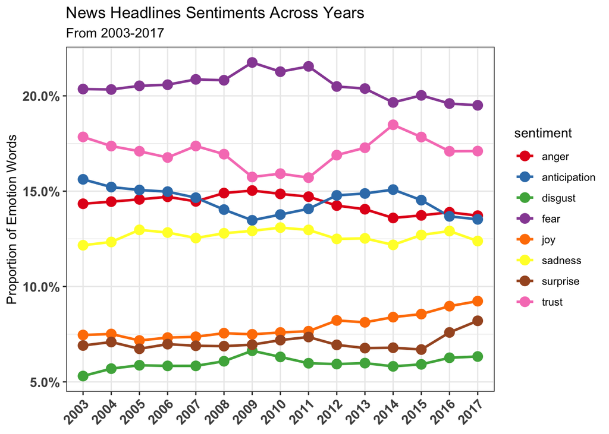

```r
news_nrc2 <- tidy_news %>%
  left_join(get_sentiments("nrc"), by = "word") %>%
  filter(!(sentiment == "negative" |
             sentiment == "positive")) %>%
  mutate(sentiment = as.factor(sentiment)) %>%
  group_by(year, sentiment) %>%
  summarize(n = n()) %>%
  mutate(percent = n / sum(n)) %>%
  select(-n) %>%
  ungroup()


news_nrc2 %>%
  group_by(year) %>%
  ggplot(aes(year, percent, color = sentiment,
             group = sentiment)) +
  geom_line(size = 1) +
  geom_point(size = 3.5) +
  scale_y_continuous(breaks = pretty_breaks(5),
                     labels = percent_format()) +
  xlab("Year") + ylab("Proportion of Emotion Words") +
  ggtitle("News Headlines Sentiments Across Years",
          subtitle = "From 2003-2017") +
  theme_bw() +
  theme(axis.text.x = element_text(angle = 45,
                                   hjust = 1, size = 11,
                                   face = "bold"),
        axis.title.x = element_blank(),
        axis.text.y = element_text(size = 11,
                                   face = "bold")) +
  scale_color_brewer(palette = "Set1")
```

We can see that the sentiment changes over time is quite consistent, with fear sentiment already at high level in 2003.

Let’s see what are the most words used that are associated with fear:

```r
nrc_fear <- get_sentiments("nrc") %>%
  filter(sentiment == "fear")

tidy_news %>%
  inner_join(nrc_fear) %>%
  count(word, sort = TRUE)
```

```
## # A tibble: 1,300 x 2
##    word           n
##    <chr>      <int>
##  1 police     35985
##  2 court      16380
##  3 fire       13910
##  4 crash      11208
##  5 death      11173
##  6 murder      9217
##  7 hospital    8815
##  8 accused     8094
##  9 government  7905
## 10 missing     7582
## # ... with 1,290 more rows
```

## Comparing how sentiments differ across the sentiment libraries

There’s three options for sentiment lexicons, let’s see how the three sentiment lexicon differ when used for these headlines.

First, let’s see how many positive and negative words each lexicon categorized.

### Bing

```r
get_sentiments("bing") %>%
  count(sentiment)
```

```
## # A tibble: 2 x 2
##   sentiment     n
##   <chr>     <int>
## 1 negative   4782
## 2 positive   2006
```

### NRC

```r
get_sentiments("nrc") %>%
  count(sentiment)
```

```
## # A tibble: 10 x 2
##    sentiment        n
##    <chr>        <int>
##  1 anger         1247
##  2 anticipation   839
##  3 disgust       1058
##  4 fear          1476
##  5 joy            689
##  6 negative      3324
##  7 positive      2312
##  8 sadness       1191
##  9 surprise       534
## 10 trust         1231
```

- Bing: there are 4782 words that can be categorized as negative, and 2006 positive.
- NRC : there are 3324 words that are categorized as negative, and 2312 positive.

The proportion of negative words in Bing lexicon is much higher than proportion of negative words in NRC lexicon.

Let’s count how many words in our text are categorized for each sentiment:

```r
# Bing lexicon
tidy_news %>%
  left_join(get_sentiments("bing"), by = "word") %>%
  group_by(sentiment) %>%
  summarize(sum = n())
```

```
## # A tibble: 3 x 2
##   sentiment     sum
##   <chr>       <int>
## 1 negative   442853
## 2 positive   195508
## 3 <NA>      4706155
```

```r
# nrc lexicon
tidy_news %>%
  left_join(get_sentiments("nrc"), by = "word") %>%
  group_by(sentiment) %>%
  summarize(sum = n())
```

```
## # A tibble: 11 x 2
##    sentiment        sum
##    <chr>          <int>
##  1 anger         306856
##  2 anticipation  309873
##  3 disgust       127805
##  4 fear          438814
##  5 joy           168191
##  6 negative      555330
##  7 positive      518200
##  8 sadness       270419
##  9 surprise      150105
## 10 trust         363695
## 11 <NA>         4027259
```

In summary, NRC lexicon managed to categorized the words much more than Bing lexicon did.

Let’s see how AFINN lexicon categorized the words now, as it’s the only lexicon we haven’t touched yet in the tidytext package! The AFINN lexicon gives a score from -5 (for negative sentiment) to +5 (positive sentiment).

### AFINN

```r
headlines_afinn <- tidy_news %>%
  left_join(get_sentiments("afinn"), by = "word") %>%
  filter(!grepl('[0-9]', word))

# count NA category
headlines_afinn %>%
    summarize(NAs= sum(is.na(score)))
```

```
## # A tibble: 1 x 1
##       NAs
##     <int>
## 1 4584704
```

```r
headlines_afinn %>%
  select(score) %>%
  mutate(sentiment = if_else(score > 0,
                             "positive", "negative",
                             "NA")) %>%
  group_by(sentiment) %>%
  summarize(sum = n())
```

```
## # A tibble: 3 x 2
##   sentiment     sum
##   <chr>       <int>
## 1 NA        4584704
## 2 negative   469070
## 3 positive   204720
```

```r
afinn_scores <- headlines_afinn %>%
  replace_na(replace = list(score = 0)) %>%
  group_by(index = linenumber %/% 10000) %>%
  summarize(sentiment = sum(score)) %>%
  mutate(lexicon = "AFINN")

# combine the Bing and NRC lexicons into one data frame:

bing_nrc_scores <- bind_rows(
  tidy_news %>%
    inner_join(get_sentiments("bing")) %>%
    mutate(lexicon = "Bing"),
  tidy_news %>%
    inner_join(get_sentiments("nrc") %>%
                 filter(sentiment %in% c("positive",
                                         "negative"))) %>%
    mutate(lexicon = "NRC")) %>%
  # from here we count the sentiments,
  ## then spread on positive/negative, then create the score:
  count(lexicon, index = linenumber %/% 10000,
        sentiment) %>%
  spread(sentiment, n, fill = 0) %>%
  mutate(lexicon = as.factor(lexicon),
         sentiment = positive - negative)

# combine all lexicons into one data frame
all_lexicons <- bind_rows(afinn_scores, bing_nrc_scores)
lexicon_cols <- c("AFINN" = "#E41A1C",
                  "NRC" = "#377EB8", "Bing" = "#4DAF4A")

all_lexicons
```

```
## # A tibble: 333 x 5
##    index sentiment lexicon negative positive
##    <dbl>     <dbl> <chr>      <dbl>    <dbl>
##  1     0     -5364 AFINN         NA       NA
##  2     1     -3761 AFINN         NA       NA
##  3     2     -3952 AFINN         NA       NA
##  4     3     -4294 AFINN         NA       NA
##  5     4     -4481 AFINN         NA       NA
##  6     5     -4077 AFINN         NA       NA
##  7     6     -4979 AFINN         NA       NA
##  8     7     -4659 AFINN         NA       NA
##  9     8     -5018 AFINN         NA       NA
## 10     9     -5087 AFINN         NA       NA
## # ... with 323 more rows
```

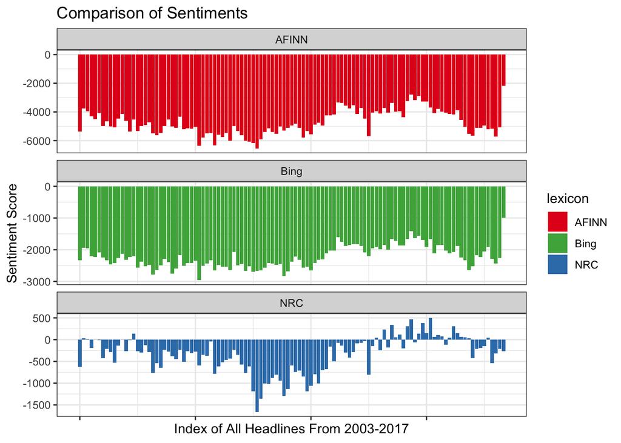

```r
all_lexicons %>%
  ggplot(aes(index, sentiment, fill = lexicon)) +
  geom_col() +
  facet_wrap(~lexicon, ncol = 1, scales = "free_y") +
  scale_fill_manual(values = lexicon_cols) +
  ggtitle("Comparison of Sentiments") +
  labs(x = "Index of All Headlines From 2003-2017" ,
       y = "Sentiment Score") +
  theme_bw() +
  theme(axis.text.x = element_blank())
```

We can see that **AFINN** and **Bing** lexicon sentiment across the years have been negative, there’s really no positive sentiment at all! But we can see in the latest index the negative score is really small, is the trend changing? we need more data to confirm that.

## Summary

It is important to note that lexicons in the `tidytext` package are not the be all and end all for text/sentiment analysis. One can even create their own lexicons through crowd-sourcing (such as Amazon Mechanical-Turk, which is how some of the lexicons shown here were created), from utilizing word lists accrued by your own company throughout the years dealing with customer/employee feedback, etc. It would be interesting to compare this datasets with headlines from another country. For example, we can compare the most focused term used by headlines in different country using the tf-idf statistic.